# Dealing with Data

There are several aspects of dealing with data.

- You need to know how to take your data from a file or a web resource and represent it in your program.
- Your data need not be in a form required to perform various analysis - you need to tidy it up.
- Your data can be a mixture of high quality data, low quality and missing data.
- Your data is in one form but the intended analysis algorithm needs it in another form.
- Sometimes units are not correct or uniform.
- Data contains duplicate entries owing to the procedure of how it was recorded.

**How do we deal with these issues?**

### Definitely not in Pure Python

You can in principle use Python libraries to take data in a string form from almost any resource around the world. Then if-else and while will indeed help you to get your data organized in a structure amenable to analysis but there are several problems

- Performance in general of such routines will be poor.
- You will end up struggling more with code and have left no energy for actual analysis.

### Numpy is better

It provides high performance arrays to organize data and further gives several methods to query these arrays for useful information. But even here, you will spend more time maintaining relationships between various arrays than the actual data.

### Enter Pandas

Pandas builds on top of Numpy and provides even more sophisticated data structures so that you spend very little time with technical aspects and more on the data.

### So, what is `pandas`?

It is an open source Python library developed by Wes McKinney.

- It offers various data structures to represent structured data.
- Provides several functions commonly needed for handling such data.
- Gives several methods to retrieve data from various sources.
- Provides high level interface to matplotlib to take care of several visualization aspects for you.
- And much more...

# Getting Started

`pandas` is a third party library and not a standard module. It must therefore be installed. If you are using a distribution like Anaconda, you already have it. Else you need to install it.

The standard imports in typical Pandas programs include:

```python
import numpy as np # We will use lots of Numpy functions in tandem with Pandas.
import pandas as pd
from pandas import Series, DataFrame # These are so often used, they are directly imported.
```

## The 'Series'

Let us begin with the building block in Pandas, known as Series. Let us start with a Numpy array first.

```python
a = np.array([1,4,64,23,11])
print(a[0]) # access by position
b = np.array([54,23,132,23,12]) # another array
print(a+b) # position matched arithmetic
```

```
1
[ 55  27 196  46  23]
```

Now, consider a sort of a Numpy array where one can obviously access by position but also through 'labels'. Further, when performing operations between two such data structures, it is not the position but the label which matters. **That's a Series.**

```python
# Let's make a Series from a list.
s = Series([1,2,3,4,5])
print(s)
```

```
0    1
1    2
2    3
3    4
4    5
dtype: int64
```

**What is that column on the left?** These are the labels assigned to each of our value. Since we did not specify any label, pandas chose integer sequence starting from 0 to N-1 where N is number of integers.

**What is that column on the right?** Those are our actual values.

Notice that pandas can see we have supplied all integers and chooses the int64 Numpy data type for our representation.

The way we have constructured our first Series, it almost seems like a Numpy array. Time to change that. Let's specify our own labels now.

```python
s = Series([1,2,3,4,5], index=['a', 'b', 'c', 'd', 'e'])
print(s)
```

```
a    1
b    2
c    3
d    4
e    5
dtype: int64
```

```python
# Access elements by index labels now.
print(s['a'])
print(s['e'])
```

```
1
5
```

What if I try to access elements as if it were a Numpy array? It will work.

```python
print(s[0])
print(s[3])
```

```
1
4
```

**BEWARE**: `s[0]` works as follows

- It searches for index label 0.
- When it realizes that index labels don't contain integers, it interprets 0 as a position.

Confusing? No problem, let's see this with an example. Let's reconstruct our Series to have an integer based index.

```python
s = Series([1,2,3,4,5], index=[2,3,4,5,6])
print(s)
```

```
2    1
3    2
4    3
5    4
6    5
dtype: int64
```

```python
print(s[2])
print(s[5])
print(s[0])
```

```
1
4
```

[output not shown]

So, you mean to say that when my index is made up of integers, I lose my ability to access by position? Not quite. What we are saying is that [] operator always looks for index labels. When given an integer and *if index is not integer based*, it falls back to searching by position.

You can still search by position:

```python
print(s.iloc[0])
print(s.iloc[5])
```

```
1
```

[output not shown]

I hate this already! This is confusing! That means someone trying to understand my programs has to worry about indexes being or not being integers to understand why I wrote s[0]!

Well, you can make things easy for them by not directly using [] at all for integer indexes.

```python
# When accessing by index labels, say
print(s.loc[4])

# When accessing by position (I)index, say
print(s.iloc[4])
```

```
3
5
```

Before we first understand the Series in more detail, let us just mention one more method of initializing a Series object.

```python
s = Series({'a': 1, 'b': 2, 'c': 3, 'd': 4, 'e': 5})
print(s)
```

```
a    1
b    2
c    3
d    4
e    5
dtype: int64
```

### Basic Properties of a Series

```python
print(s.index)
```

```
Index(['a', 'b', 'c', 'd', 'e'], dtype='object')
```

```python
print(s.values)
```

```
[1 2 3 4 5]
```

```python
print(len(s))
print(s.size)
print(s.shape)
```

```
5
5
(5,)
```

### Previewing Data

```python
s = Series(np.arange(100), index=np.arange(100)+33)
print(s.head(3))
```

```
33    0
34    1
35    2
dtype: int64
```

```python
print(s.tail(3))
```

```
130    97
131    98
132    99
dtype: int64
```

```python
print(s.take([1,3,7]))
```

```
34    1
36    3
40    7
dtype: int64
```

### Index Labels Need not be Unique!

```python
s = Series([1,2,3,2,3], index=['a','b','a','b','e'])
print(s)
```

```
a    1
b    2
a    3
b    2
e    3
dtype: int64
```

```python
print(s['a'])
```

```
a    1
a    3
dtype: int64
```

```python
print(s.value_counts())
```

```
3    2
2    2
1    1
dtype: int64
```

```python
print(s.unique())
```

```
[1 2 3]
```

### Alignments

```python
s1 = Series([1,2,3,4,5], index=['a','b','c','d','e'])
s2 = Series([1,2,3,4,5], index=['b','c','d','e','f'])
series_sum = s1+s2
print(series_sum)
```

```
a    NaN
b    3.0
c    5.0
d    7.0
e    9.0
f    NaN
dtype: float64
```

Unlike Numpy arrays, series don'y simply add by position. They are **aligned** by their labels and then added up. If any label is missing in one and present in another, it becomes **NaN**.

### Behavior of NaNs in Pandas

```python
series_sum_array = np.array(series_sum)
print(series_sum_array.sum())
```

```
nan
```

```python
print(series_sum.sum())
print(series_sum.mean())
```

```
24.0
6.0
```

So, Numpy takes operation on elements very seriously and strictly - NaN + anything is a NaN. Pandas is lenient. It ignores NaNs and operates on the rest of the array. That is what a data analyst does need.

### Boolean Selections works as expected.

```python
import string
s = Series(np.arange(10), index=list(string.ascii_lowercase)[:10])
subset = s[(s < 5)]
print(subset)
```

```
a    0
b    1
c    2
d    3
e    4
dtype: int64
```

### Index can be changed after the fact.

```python
s.index = list(string.ascii_lowercase[10:20])
print(s.head(3))
```

```
k    0
l    1
m    2
dtype: int64
```

```python
snew = s.reindex(['p','q','r'])
print(snew)
```

```
p    5
q    6
r    7
dtype: int64
```

reindex() offers a bunch of other methods to control output.

```python
snew = s.reindex(['p','q','r', 'za', 'ka'], fill_value=0)
print(snew)
```

```
p     5
q     6
r     7
za    0
ka    0
dtype: int64
```

```python
snew = s.reindex(['p','q','r', 'f', 'g'], method='bfill')
print(snew)
```

```
p    5
q    6
r    7
f    0
g    0
dtype: int64
```

### Slicing still makes a view.

```python
s = Series([1,2,3,4,5], index=['a','b','c','d','e'])
snew = s['c':'e']
snew['c'] = 4434
print(s)
```

```
a       1
b       2
c    4434
d       4
e       5
dtype: int64
```

```python
snew = s.copy()
# ....
```

# DataFrames

While a Series object is a structure for 1-d data, DataFrames are structures meant for 2-d data. One way to think about them is a dictionary of Series with keys representing 'column names' and a common index for all the Series objects. Another way to think about them is a 2-d matrix with an index marking the rows and column names marking the columns.

Even from the point of view of making a DataFrame object, both these ways of visualizing a DataFrame hold good. Let's see.

```python
# As a dictionary of Series
s1 = Series(np.arange(10))
s2 = Series(np.arange(10)+2)
s3 = Series(np.arange(10)+4)

df = DataFrame({'colA': s1, 'colB': s2, 'colC': s3})
print(df)
```

```
   colA  colB  colC
0     0     2     4
1     1     3     5
2     2     4     6
3     3     5     7
4     4     6     8
5     5     7     9
6     6     8    10
7     7     9    11
8     8    10    12
9     9    11    13
```

```python
# As a 2-d matrix of data.

data = np.random.rand(30).reshape(10,3)
df = DataFrame(data, columns=['colA', 'colB', 'colC'], index=np.arange(10)+100)
print(df)
```

```
         colA      colB      colC
100  0.836710  0.062906  0.406728
101  0.706797  0.061152  0.303993
102  0.339733  0.295066  0.012426
103  0.321418  0.327401  0.369663
104  0.344695  0.313315  0.945308
105  0.992973  0.198912  0.597153
106  0.379810  0.570965  0.230758
107  0.230408  0.710735  0.779433
108  0.171350  0.212493  0.251289
109  0.271423  0.982873  0.932947
```

### Accessing Data

The [ ] operator of the Series object will lookup by index labels. But in case of DataFrames it is designed to look at columns by default.

```python
s = df['colA']
# s is a Series
print(s)
```

```
100    0.836710
101    0.706797
102    0.339733
103    0.321418
104    0.344695
105    0.992973
106    0.379810
107    0.230408
108    0.171350
109    0.271423
Name: colA, dtype: float64
```

```python
print(type(s))
```

```
<class 'pandas.core.series.Series'>
```

You can also access by column position but then you will need to provide a list as input.

```python
print(df[[0]].head())
```

```
         colA
100  0.836710
101  0.706797
102  0.339733
103  0.321418
104  0.344695
```

```python
# And also access multiple columns.
print(df[[0,2]].head())
```

```
         colA      colC
100  0.836710  0.406728
101  0.706797  0.303993
102  0.339733  0.012426
103  0.321418  0.369663
104  0.344695  0.945308
```

A very convenient way of accessing columns is to treat them as attributes of the DataFrame object but this is possible only if the name of the column in a single word satisfying all the rules of naming a variable.

```python
print(df.colA)
```

```
100    0.836710
101    0.706797
102    0.339733
103    0.321418
104    0.344695
105    0.992973
106    0.379810
107    0.230408
108    0.171350
109    0.271423
Name: colA, dtype: float64
```

But if [ ] operator of a DataFrame is going to select columns, how does one go about selecting the rows? Well, the [ ] operator definitely does access columns except **when slices are provided**.

```python
print(df[1:4]) # 1:4 are interpreted as positions not index labels.
```

```
         colA      colB      colC
101  0.706797  0.061152  0.303993
102  0.339733  0.295066  0.012426
103  0.321418  0.327401  0.369663
```

```python
print(df[101:103]) # Elements of this position don't exist.
```

```
Empty DataFrame
Columns: [colA, colB, colC]
Index: []
```

A less ambigious way of dealing with the row-wise access is to use .loc and .iloc attributes of the DataFrame.

```python
df.loc[101] # gives out a Series whose index=columns
```

```
colA    0.706797
colB    0.061152
colC    0.303993
Name: 101, dtype: float64
```

```python
df.iloc[0] # does same but position wise
```

```
colA    0.836710
colB    0.062906
colC    0.406728
Name: 100, dtype: float64
```

And finally, how about accessing a single value? You could of course chain the above syntaxes.

```python
print(df['colA'][101])
```

```
0.706796563266
```

Or use the more readable .at() or .iat() attributs.

```python
print(df.at[101, 'colB'])
print(df.iat[0,0]) # position wise
```

```
0.061152061057
0.836709626026
```

And yes, you can do a Boolean selection by extending above rules.

## Basic modifications to a DataFrame

```python
# Renaming a column.
df.rename(columns={'colA': 'colAA'}, inplace=True)
print(df)
```

```
        colAA      colB      colC
100  0.836710  0.062906  0.406728
101  0.706797  0.061152  0.303993
102  0.339733  0.295066  0.012426
103  0.321418  0.327401  0.369663
104  0.344695  0.313315  0.945308
105  0.992973  0.198912  0.597153
106  0.379810  0.570965  0.230758
107  0.230408  0.710735  0.779433
108  0.171350  0.212493  0.251289
109  0.271423  0.982873  0.932947
```

```python
# Adding a new column.
df['colD'] = df['colAA']*2
print(df)
```

```
        colAA      colB      colC      colD
100  0.836710  0.062906  0.406728  1.673419
101  0.706797  0.061152  0.303993  1.413593
102  0.339733  0.295066  0.012426  0.679466
103  0.321418  0.327401  0.369663  0.642836
104  0.344695  0.313315  0.945308  0.689390
105  0.992973  0.198912  0.597153  1.985946
106  0.379810  0.570965  0.230758  0.759621
107  0.230408  0.710735  0.779433  0.460816
108  0.171350  0.212493  0.251289  0.342701
109  0.271423  0.982873  0.932947  0.542846
```

If you wanted to insert it in an arbitrary position,

```
df.insert(2, 'colD', df['colAA']*2)
```

```python
# Replacing columns
df['colD'] = np.arange(1,11)*4
print(df)
```

```
        colAA      colB      colC  colD
100  0.836710  0.062906  0.406728     4
101  0.706797  0.061152  0.303993     8
102  0.339733  0.295066  0.012426    12
103  0.321418  0.327401  0.369663    16
104  0.344695  0.313315  0.945308    20
105  0.992973  0.198912  0.597153    24
106  0.379810  0.570965  0.230758    28
107  0.230408  0.710735  0.779433    32
108  0.171350  0.212493  0.251289    36
109  0.271423  0.982873  0.932947    40
```

```python
# Deleting Columns
del df['colD']
print(df)
```

```
        colAA      colB      colC
100  0.836710  0.062906  0.406728
101  0.706797  0.061152  0.303993
102  0.339733  0.295066  0.012426
103  0.321418  0.327401  0.369663
104  0.344695  0.313315  0.945308
105  0.992973  0.198912  0.597153
106  0.379810  0.570965  0.230758
107  0.230408  0.710735  0.779433
108  0.171350  0.212493  0.251289
109  0.271423  0.982873  0.932947
```

Other ways to delete columns.

```
deletedColumn = df.pop('colD')
df = df.drop(['colD'], axis=1)
```

```python
# Deleting rows.
df = df.drop([101,104])
print(df)
```

```
        colAA      colB      colC
100  0.836710  0.062906  0.406728
102  0.339733  0.295066  0.012426
103  0.321418  0.327401  0.369663
105  0.992973  0.198912  0.597153
106  0.379810  0.570965  0.230758
107  0.230408  0.710735  0.779433
108  0.171350  0.212493  0.251289
109  0.271423  0.982873  0.932947
```

```python
# Adding a new row.
df.loc[104] = [12, 13, 14]
print(df)
```

```
         colAA       colB       colC
100   0.836710   0.062906   0.406728
102   0.339733   0.295066   0.012426
103   0.321418   0.327401   0.369663
105   0.992973   0.198912   0.597153
106   0.379810   0.570965   0.230758
107   0.230408   0.710735   0.779433
108   0.171350   0.212493   0.251289
109   0.271423   0.982873   0.932947
104  12.000000  13.000000  14.000000
```

## Operations With Multiple DataFrames

```python
data = np.random.rand(30).reshape(10,3)
df1 = DataFrame(data, columns=['colA', 'colB', 'colC'], index=np.arange(10)+100)
df2 = DataFrame(data, columns=['colA', 'colB', 'colC'], index=np.arange(10)+104)

combined = pd.concat([df1, df2])
print(combined)
```

```
         colA      colB      colC
100  0.503348  0.021052  0.962284
101  0.303766  0.521687  0.716441
102  0.157751  0.761292  0.950204
103  0.452395  0.303905  0.296932
104  0.603843  0.914682  0.408714
105  0.579555  0.307238  0.005761
106  0.547780  0.349432  0.903410
107  0.671178  0.095884  0.917567
108  0.456895  0.020406  0.873115
109  0.889798  0.845573  0.380665
104  0.503348  0.021052  0.962284
105  0.303766  0.521687  0.716441
106  0.157751  0.761292  0.950204
107  0.452395  0.303905  0.296932
108  0.603843  0.914682  0.408714
109  0.579555  0.307238  0.005761
110  0.547780  0.349432  0.903410
111  0.671178  0.095884  0.917567
112  0.456895  0.020406  0.873115
113  0.889798  0.845573  0.380665
```

So, we learn two important things about pdf.concat()

- It combines vertically.
- And it disregards index duplication.

We can request it to reconstruct our index.

```python
combined = pd.concat([df1, df2], ignore_index=True)
print(combined)
```

```
        colA      colB      colC
0   0.503348  0.021052  0.962284
1   0.303766  0.521687  0.716441
2   0.157751  0.761292  0.950204
3   0.452395  0.303905  0.296932
4   0.603843  0.914682  0.408714
5   0.579555  0.307238  0.005761
6   0.547780  0.349432  0.903410
7   0.671178  0.095884  0.917567
8   0.456895  0.020406  0.873115
9   0.889798  0.845573  0.380665
10  0.503348  0.021052  0.962284
11  0.303766  0.521687  0.716441
12  0.157751  0.761292  0.950204
13  0.452395  0.303905  0.296932
14  0.603843  0.914682  0.408714
15  0.579555  0.307238  0.005761
16  0.547780  0.349432  0.903410
17  0.671178  0.095884  0.917567
18  0.456895  0.020406  0.873115
19  0.889798  0.845573  0.380665
```

The same pdf.concat() can also be used to combine two dataframes horizontally.

```python
combined = pd.concat([df1, df2], axis=1)
print(combined)
```

```
         colA      colB      colC      colA      colB      colC
100  0.503348  0.021052  0.962284       NaN       NaN       NaN
101  0.303766  0.521687  0.716441       NaN       NaN       NaN
102  0.157751  0.761292  0.950204       NaN       NaN       NaN
103  0.452395  0.303905  0.296932       NaN       NaN       NaN
104  0.603843  0.914682  0.408714  0.503348  0.021052  0.962284
105  0.579555  0.307238  0.005761  0.303766  0.521687  0.716441
106  0.547780  0.349432  0.903410  0.157751  0.761292  0.950204
107  0.671178  0.095884  0.917567  0.452395  0.303905  0.296932
108  0.456895  0.020406  0.873115  0.603843  0.914682  0.408714
109  0.889798  0.845573  0.380665  0.579555  0.307238  0.005761
110       NaN       NaN       NaN  0.547780  0.349432  0.903410
111       NaN       NaN       NaN  0.671178  0.095884  0.917567
112       NaN       NaN       NaN  0.456895  0.020406  0.873115
113       NaN       NaN       NaN  0.889798  0.845573  0.380665
```

Notice that `pd.concat(..., axis=1)` does a join or alignment using index labels. Sometimes we want to achieve this join not using index labels but using some columns which are common to two tables. Example, we have one table

Students

```
StudID | Name | Age | Gender
```

Student Marks

```
StudID | Subject | Marks
```

Let's assume we are using default generated index labels for both dataframes but for combining the data we don't want to use these. We'd rather use StudID which is common to both tables. This is where you use merge()

```
combined = df1.merge(df2)
```

## Other cools things to do with DataFrames

### Handling Missing Data

Recall our combined data frame from previous examples. As can be seen below, it contains a lot of NaN values. This is because data in those locations are missing. This could very well be a realistic data set. Before we proceed with analysis, we'd like to handle these NaN values.

```python
print(combined)
```

```
         colA      colB      colC      colA      colB      colC
100  0.503348  0.021052  0.962284       NaN       NaN       NaN
101  0.303766  0.521687  0.716441       NaN       NaN       NaN
102  0.157751  0.761292  0.950204       NaN       NaN       NaN
103  0.452395  0.303905  0.296932       NaN       NaN       NaN
104  0.603843  0.914682  0.408714  0.503348  0.021052  0.962284
105  0.579555  0.307238  0.005761  0.303766  0.521687  0.716441
106  0.547780  0.349432  0.903410  0.157751  0.761292  0.950204
107  0.671178  0.095884  0.917567  0.452395  0.303905  0.296932
108  0.456895  0.020406  0.873115  0.603843  0.914682  0.408714
109  0.889798  0.845573  0.380665  0.579555  0.307238  0.005761
110       NaN       NaN       NaN  0.547780  0.349432  0.903410
111       NaN       NaN       NaN  0.671178  0.095884  0.917567
112       NaN       NaN       NaN  0.456895  0.020406  0.873115
113       NaN       NaN       NaN  0.889798  0.845573  0.380665
```

One strategy is to drop all rows which contain even one NaN

```python
cleaned = combined.dropna()
print(cleaned)
```

```
         colA      colB      colC      colA      colB      colC
104  0.603843  0.914682  0.408714  0.503348  0.021052  0.962284
105  0.579555  0.307238  0.005761  0.303766  0.521687  0.716441
106  0.547780  0.349432  0.903410  0.157751  0.761292  0.950204
107  0.671178  0.095884  0.917567  0.452395  0.303905  0.296932
108  0.456895  0.020406  0.873115  0.603843  0.914682  0.408714
109  0.889798  0.845573  0.380665  0.579555  0.307238  0.005761
```

dropna() accepts several options to control its behavior. Look up the documentation.

### Summary Statistics

```python
df.describe()
```

|  | colAA | colB | colC |
| --- | --- | --- | --- |
| count | 9.000000 | 9.000000 | 9.000000 |
| mean | 1.727092 | 1.817928 | 1.953377 |
| std | 3.862635 | 4.203218 | 4.526477 |
| min | 0.171350 | 0.062906 | 0.012426 |
| 25% | 0.271423 | 0.212493 | 0.251289 |
| 50% | 0.339733 | 0.327401 | 0.406728 |
| 75% | 0.836710 | 0.710735 | 0.779433 |
| max | 12.000000 | 13.000000 | 14.000000 |

### Lots of Other Stuff

We won't be able to cover lots of other cool features but just to give you an idea of what is possible, we provide below a list of topics for you to explore.

- Grouping
- Hierarchical Indexing
- Interpolating
- Handling of Duplication
- Data Transformation
- Pivoting
- Stacks
- Time Series and more.

# Loading Data

So far we have been constructing dataframes from random number generators. This is obviously for illustration purposes. But in reality, data comes from various resources such as

- Files on your computer
- The web
- An API to a data service
- Database servers etc.

Let us very quickly review the first two. The remaining two are beyond the scope of this presentation.

### A CSV File

```
df = pd.read_csv('path/to/file.csv')
```

Do you want a specific column to be used as an index?

```
df = pd.read_csv('path/to/file.csv', index_col=0) # uses 1st column as index
```

Pandas will automatically determine data types for each column. Want to specify your own?

```
df = pd.read_csv('path/to/file.csv', dtype={'colName': np.float64})
```

Wish to give your own names to the columns?

```
df = pd.read_csv('path/to/file.csv', header=0, names=['one', 'two',...])
```

Load only specific columns.

```
df = pf.read_csv('path/to/file.csv', use_cols=['col1', 'col2'])
```

### A general ASCII file.

```
df = pd.read_table('path/to/file', sep='|')
```

Have a footer of 4 lines which you need to ignore?

```
df = pd.read_table('path/to/file', sep='|', skip_footer=4)
```

```
df = pd.read_table('path/to/file', sep='|', nrows=3)
```

And more ... check documentation.

### Saving files from dataframes

Whether it's a CSV file or a plain ASCII file, the procedure for saving the file is same.

```
df.to_csv('file)
```

For generic ASCII

```
df.to_csv('file', sep='|')
```

By default, to_csv() will discard index information. To store it as a file,

```
df.to_csv('file', index_label='someColName')
```

### From and to an Excel sheet.

```
df = pd.read_excel('file.xls', sheetname='Sheet1')

df.to_excel('some.xls')
```

### From and to a JSON file dump.

```
df = pd.read_json('file.json')

df.to_json('file.json')
```

### From and to HTML pages.

```
df = pd.read_html('filename OR URL')

df.to_html('some.html')
```

Pandas has some in-built tools to directly access some commonly used web data resources. These include Yahoo! Finance for example. Refer to documentation for more details.

Pandas can directly interact with a database through a connection established using the standard Python API. Again, refer to documentation for more details.

# Visualization

Pandas does not have visualization capabilities of its own. However, it does interact with 'matplotlib' and produces very useful visualizations for you. It uses the information about the data captured in a DataFrame and does a lot of work for you - such as choosing the right axis labels, the labels for the legends etc.

Especially if you are using a Notebook, it is better to set some options before we get started.

```python
import numpy as np
import pandas as pd
from pandas import Series, DataFrame

import matplotlib as mpl
import matplotlib.pyplot as plt
%matplotlib inline
```

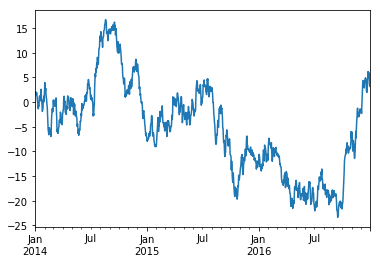

```python
# Let's just do a random walk using a Series.
# The index is a time series generated using Pandas.

np.random.seed(333)
s = pd.Series(np.random.randn(1096),
index=pd.date_range('2014-01-01', '2016-12-31'))
random_ts = s.cumsum()
# this plots the walk - just that easy :)
random_ts.plot();
```

```python
# Let us load a file.
jor = pd.read_table('jor_r.csv', sep=' ')
print(jor.head())
```

```
   lgrekpc  lgsig   lgIe
0   0.1846  1.876  18.46
1   0.4546  2.040  18.32
2   0.3946  2.186  18.59
3   1.1650  2.412  17.94
4   0.6446  2.111  18.21
```

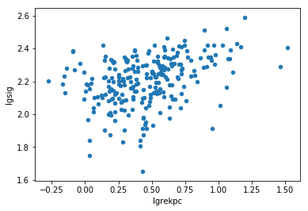

```python
# A scatter plot between lgrekpc and lgsig

jor.plot(kind='scatter', x='lgrekpc', y='lgsig')
```

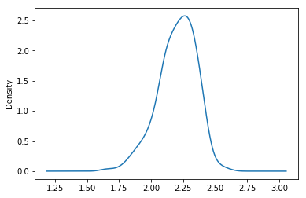

```python
# A Kernel Density Estimator plot.
jor.lgsig.plot(kind='kde', x='lgsig')
```

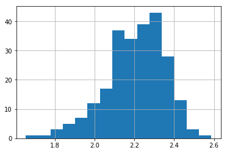

```python
# A histogram
jor.lgsig.hist(bins=15)
```

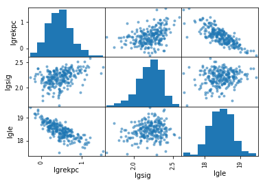

```python
# Scatter Matrix aka Pairs Plot
pd.scatter_matrix(jor, diagonal='hist')
print()
```